# Stock Assessment Using LBSPR

Selected species of tuna and tuna-like fish in Somalia Water

Author

Rushingisha George, Masumbuko Semba, and Mathew Silas

Published

December 16, 2025

Modified

December 19, 2025

## Introduction

This document provides a step-by-step guide to performing a stock assessment simulation using the **Length-Based Spawning Potential Ratio (LBSPR)** method. LBSPR is a powerful technique for assessing the health of fish stocks, especially in data-limited situations where traditional age-based data is unavailable.

We will first simulate a fish population with known biological and fishery characteristics to understand how the LBSPR model works. This simulation will generate an expected length-frequency distribution, which can later be compared against real-world data collected from fisheries.

## Setting Up the R Environment

The first step is to load the necessary R packages. Each package provides a specific set of tools required for our analysis.

- **`tidyverse`**: A collection of R packages for data manipulation and visualization.
- **`LBSPR`**: The core package for this analysis, containing all functions for the LBSPR method.
- **`TropFishR`**: A package for tropical fish stock assessment, which can be useful for related analyses.
- **`gt`**: For creating beautiful and presentation-ready tables.
- **`sizeMat`**: A package for estimating size at maturity, a key input for LBSPR.

```r
# Load required libraries
require(tidyverse) # Data manipulation and visualization
require(tidyplots) # Easy plotting
require(LBSPR)     # Length-Based Spawning Potential Ratio analysis
require(sizeMat)   # Estimate size at maturity
require(gt)        # Create presentation-ready tables
require(TropFishR) # Tropical fisheries stock assessment methods
```

# Approach

## Read data

The first step in any data analysis is to load the data. Our fisheries data, containing length, weight, species, and catch information, is stored in a CSV (Comma-Separated Values) file named `lw2.csv`. The following code chunk reads this file into our R environment and stores it in a data frame called `lw`. This data frame will be the foundation for all subsequent steps in our stock assessment.

```r
lw = read_csv("lw2.csv")
```

### Model Fish Group: Yellowfin Tuna

**What we’re doing:** We need to isolate data for a single species to conduct a stock-specific assessment. Here we filter for Yellowfin Tuna (YFT) from the larger dataset.

**Why it matters:** Each fish species has different growth rates, maturity schedules, and fishing characteristics. By focusing on one species, we can accurately estimate its population parameters.

```r
yft = lw |>
    filter(fish_type_code == 'YFT')
```

### Explore Length-Weight Relationship

**What we’re doing:** We create a scatter plot showing how length and weight relate to each other for Yellowfin Tuna across different regions, with a fitted curve.

**What to look for:**

- A smooth, curved relationship indicates normal growth patterns
- Outliers might represent data entry errors
- Different regions may show different growth patterns

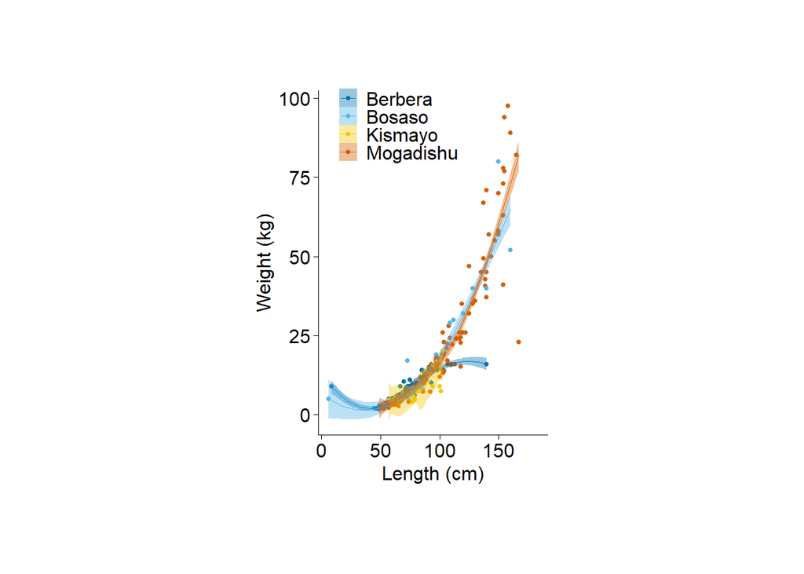

```r
yft |>
  tidyplot(x = length_cm, y = weight_kg, color = region) |>
  add_data_points() |>
  add_curve_fit() |>
  adjust_size(width = 2, height = 3, unit = 'in') |>
  adjust_font(fontsize = 12) |>
  adjust_legend_position(position = c(.35, .9)) |>
  adjust_x_axis(title = 'Length (cm)') |>
  adjust_y_axis(title = 'Weight (kg)') |>
  remove_legend_title()
```

### Data Quality Filter

**What we’re doing:** Remove potentially problematic data points (fish from Berbera region and very small fish under 20 cm).

**Why it matters:**

- Small fish may be juveniles with different growth patterns
- Regional data quality issues may affect estimates
- Cleaner data = more reliable assessment results

```r
yft = lw |>
    filter(fish_type_code == 'YFT' & !region == 'Berbera' & length_cm > 20)
```

### Maturity Classification

**What we’re doing:** Separate fish into two groups—mature (able to reproduce) and immature (not yet reproductive)—using statistical analysis of length and weight patterns.

**Why it matters:** Maturity schedules are critical for LBSPR because:

- The model needs to know at what size fish can first reproduce (L50)
- Fishing immature fish reduces population recovery ability
- Management often protects immature fish to ensure stock replenishment

```r
## Partitioning with Frequentist regression
classified_yft <- yft |>
  classify_mature(
    varNames = c("length_cm", "weight_kg"),
    varSex = NULL,
    selectSex = NULL,
    method = "ld"
  )
```

```
all individuals were used in the analysis
```

```r
classified_yft
```

```
Number in juvenile group = 272

Number in adult group = 98

--------------------------------------------------------
1) Linear regression for juveniles

Call:
glm(formula = y ~ x, data = juv)

Coefficients:
             Estimate Std. Error t value Pr(>|t|)
(Intercept) -9.184692   0.513034  -17.90   <2e-16 ***
x            0.220284   0.007291   30.21   <2e-16 ***
---
Signif. codes:  0 '***' 0.001 '**' 0.01 '*' 0.05 '.' 0.1 ' ' 1

(Dispersion parameter for gaussian family taken to be 1.638605)

    Null deviance: 1938.03  on 271  degrees of freedom
Residual deviance:  442.42  on 270  degrees of freedom
AIC: 910.22

Number of Fisher Scoring iterations: 2

--------------------------------------------------------
2) Linear regression for adults

Call:
glm(formula = y ~ x, data = adt)

Coefficients:
            Estimate Std. Error t value Pr(>|t|)
(Intercept) -69.6649     5.7059  -12.21   <2e-16 ***
x             0.8608     0.0478   18.01   <2e-16 ***
---
Signif. codes:  0 '***' 0.001 '**' 0.01 '*' 0.05 '.' 0.1 ' ' 1

(Dispersion parameter for gaussian family taken to be 106.3829)

    Null deviance: 44716  on 97  degrees of freedom
Residual deviance: 10213  on 96  degrees of freedom
AIC: 739.46

Number of Fisher Scoring iterations: 2

--------------------------------------------------------
3) Difference between slopes (ANCOVA)
               Estimate Std. Error    t value     Pr(>|t|)
(Intercept)  -9.1846920 2.16246354  -4.247328 2.746951e-05
x             0.2202842 0.03073368   7.167517 4.244089e-12
mature      -60.4802433 3.68591106 -16.408492 9.644949e-46
x:mature      0.6405282 0.03962059  16.166549 9.554434e-45
[1] "slopes are different"
```

### Visualize Maturity Classification

**What we’re doing:** Plot the classified mature and immature fish to visually inspect the separation quality.

**What to look for:** Clear separation between mature (upper right) and immature (lower left) fish groups indicates good classification.

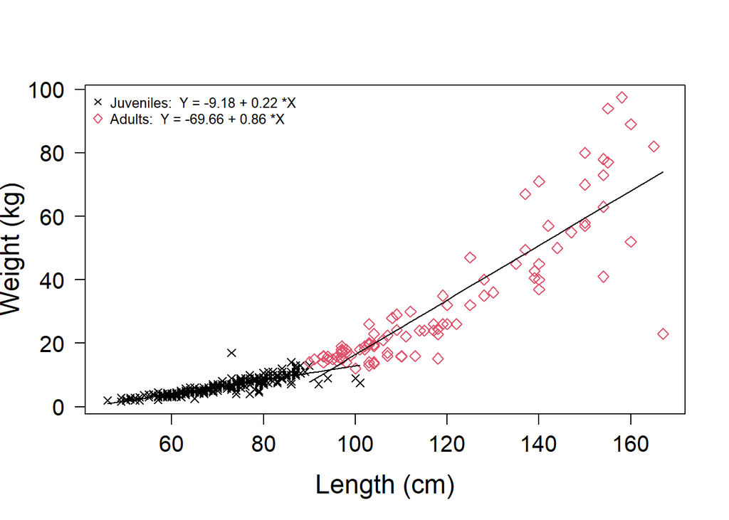

```r
classified_yft |>
  plot(
    xlab = 'Length (cm)',
    ylab = 'Weight (kg)',
    cex.main = 1.5,
    cex.lab = 1.5,
    cex.axis = 1.3,
    las = 1
  )
```

### Estimate L50 (Length at 50% Maturity)

**What we’re doing:** Calculate the length at which 50% of the population reaches maturity using a logistic regression fitted to 1000 bootstrap samples.

**Why it matters:** L50 is a key input to LBSPR because it defines when fish become vulnerable to overfishing from a reproductive standpoint.

```r
yft_ogive_fq <- classified_yft |>
  morph_mature(
    method = "fq",
    niter = 1000
)
```

### Display Maturity Parameters

**What the columns mean:**

- **A & B:** Parameters of the logistic maturity curve
- **L50:** Length (cm) where 50% of fish are mature
- **R²:** How well the curve fits the data (1.0 = perfect fit)

```r
yft_ogive_fq |>
    print() |>
    as.data.frame() |>
    as_tibble() |>
    mutate(Freq = as.numeric(Freq)) |>
    pivot_wider(names_from = Var1 , values_from  = Freq) |>
    gt() |>
    fmt_number(columns = everything(), decimals = 2) |>
    fmt_missing(columns = everything(), missing_text = '-') |>
    cols_label(
        Var2 ~ 'Variables',
        # A ~ 'A-Intercept',
        # B ~ 'B-Slope',
        L50 ~ md('L~50~'),
        R2  ~ md('R^2^')
    ) |>
    tab_spanner(columns = c('A', 'B'), label = 'Ogive Parameters') |>
    tab_options(data_row.padding = px(5), table.font.size = '12pt') |>
    cols_width(
        Var2 ~ px(200),
        A ~ px(120),
        B ~ px(70),
        L50 ~ px(70),
        R2 ~ px(70)
    ) |>
    tab_footnote(footnote = 'A for Intercept of the logistic curve.', locations = cells_column_labels(columns = 'A'))|>
    tab_footnote(footnote = 'B for slope of the logistic curve.', locations = cells_column_labels(columns = 'B'))
```

```
formula: Y = 1/1+exp-(A + B*X)
```

[output not shown]

<sup>1</sup> A for Intercept of the logistic curve.  
<sup>2</sup> B for slope of the logistic curve.

### Plot Maturity Curve

**What we’re doing:** Visualize the maturity ogive—the smooth curve showing the proportion of mature fish at each length.

**What it shows:**

- At lengths below L50, few fish are mature
- At lengths above L50, most fish are mature
- The curve typically follows an S-shape (logistic pattern)

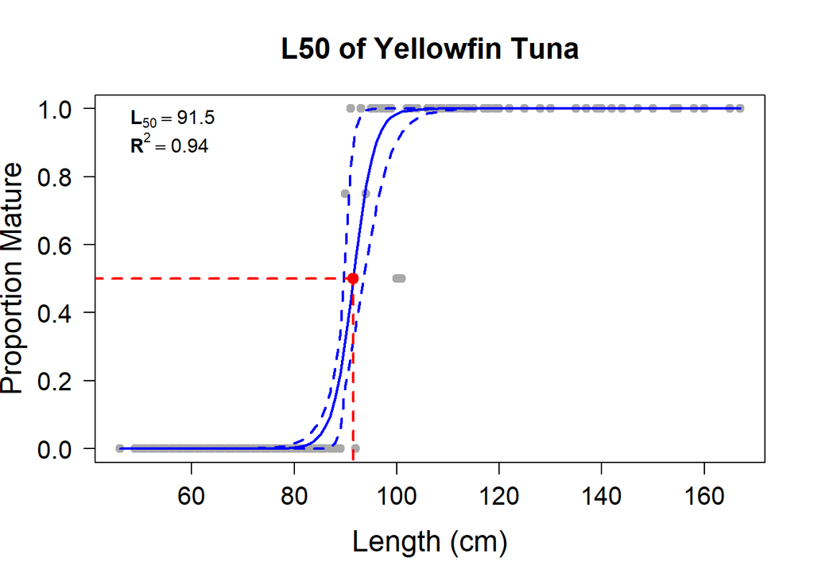

```
Size at morphometric maturity = 91.5
Confidence intervals = 89.8 - 93.4
Rsquare = 0.94
```

```r
yft_ogive_fq |>
    plot(
    main = 'L50 of Yellowfin Tuna',
    xlab = 'Length (cm)',
    ylab = 'Proportion Mature',
    cex.main = 1.5,
    cex.lab = 1.5,
    cex.axis = 1.3,
    las = 1,
    onlyOgive = TRUE
)
```

### Combine Maturity and Ogive Visualizations

**What we’re doing:** Display both the classified data and the fitted maturity curve side-by-side for comprehensive assessment quality review.

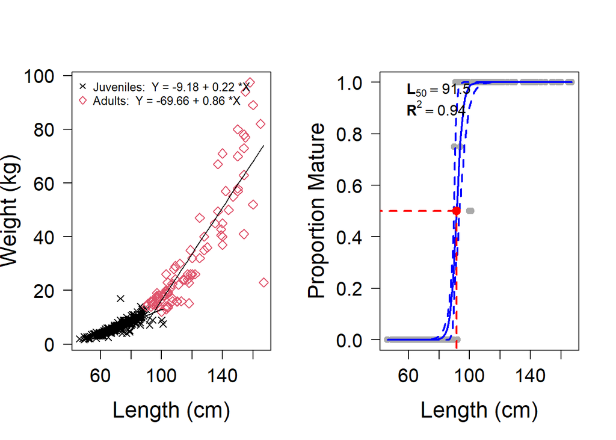

```
Size at morphometric maturity = 91.5
Confidence intervals = 89.8 - 93.4
Rsquare = 0.94
```

```r
par(mfrow = c(1,2))

classified_yft |>
  plot(
    xlab = 'Length (cm)',
    ylab = 'Weight (kg)',
    cex.main = 1.5,
    cex.lab = 1.5,
    cex.axis = 1.3,
    las = 1
  )

yft_ogive_fq |>
    plot(
    xlab = 'Length (cm)',
    ylab = 'Proportion Mature',
    cex.main = 1.5,
    cex.lab = 1.5,
    cex.axis = 1.3,
    las = 1,
    onlyOgive = TRUE
)
```

### Prepare Length-Frequency Data (LFQ)

**What we’re doing:** Convert raw individual fish measurements into length-frequency data by binning them into size classes. We also apply smoothing techniques (moving average, square root transformation).

**Why it matters:**

- LBSPR needs data organized by size classes, not individual fish
- Smoothing reduces noise from sampling variation
- This format is standard for length-based assessment methods

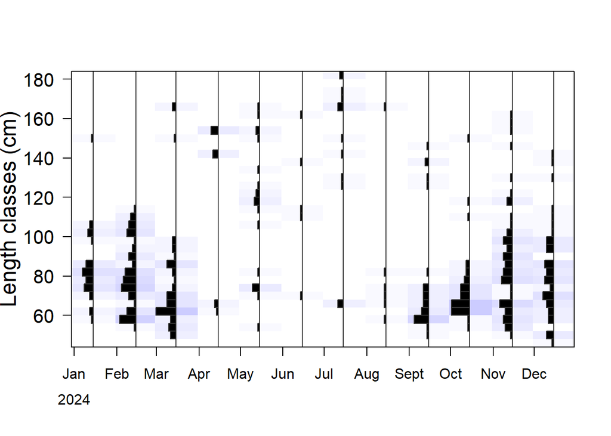

```r
par(mfrow = c(1,1))

aa = yft |>
   mutate(
    date = lubridate::make_date(year = 2024, month = month(date_dd_mm_yy), day = 15 )
    )

lfq_mod = aa |>
  TropFishR::lfqCreate(
    Lname = "length_cm",
    Dname = "date",
    bin_size = 2,
    species = "Yellowfin",
    length_unit = "cm",
    aggregate_dates = TRUE
    ) |>
  TropFishR::lfqModify(
    bin_size = 4,
    aggregate = "month",
    vectorise_catch = FALSE
    ) |>
  TropFishR::lfqRestructure(
    MA = 9,
    addl.sqrt = TRUE
    )

lfq_mod |>
    plot(
        Fname = "catch",
        las = 1,
        ylab = 'Length classes (cm)',
        cex.main = 1.5,
        cex.lab = 1.5,
        cex.axis = 1.3
    )
```

### Powell-Wetherall Method: Estimate Linf and Z

**What we’re doing:** Estimate two key parameters:

- **Linf (L∞):** The theoretical maximum length the fish can reach
- **Z (Total Mortality):** The combined death rate from fishing and natural causes

**Why it matters:** These are fundamental biological parameters needed for all subsequent growth and mortality calculations.

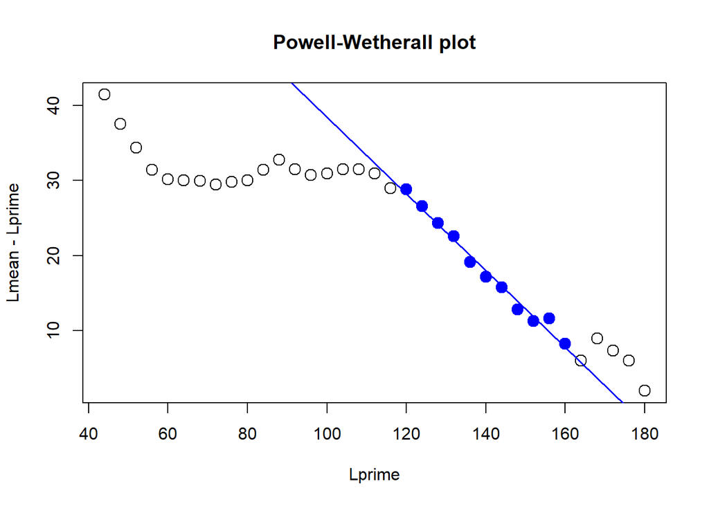

```r
par(mfrow = c(1,1))

res_PW <- powell_wetherall(param = lfq_mod,
                           catch_columns = 1:ncol(lfq_mod$catch),
                           reg_int = c(20,30)
                           )
```

```r
# show results
paste0("Linf = ", round(res_PW$Linf_est, 2), " ± ", round(res_PW$se_Linf))
```

```
[1] "Linf = 175.29 ± 13"
```

### ELEFAN: Estimate Growth Parameters (K)

**What we’re doing:** Use Electronic LEngth Frequency ANalysis (ELEFAN) with K-Scan to estimate the growth coefficient (K) from the length-frequency data.

**Why it matters:**

- K describes how quickly fish grow toward their maximum size
- Combined with Linf, it defines the von Bertalanffy growth curve
- Essential input for age calculations in LBSPR

```
Optimisation procuedure of ELEFAN is running.
This will take some time.
The process bar will inform you about the process of the calculations.
```

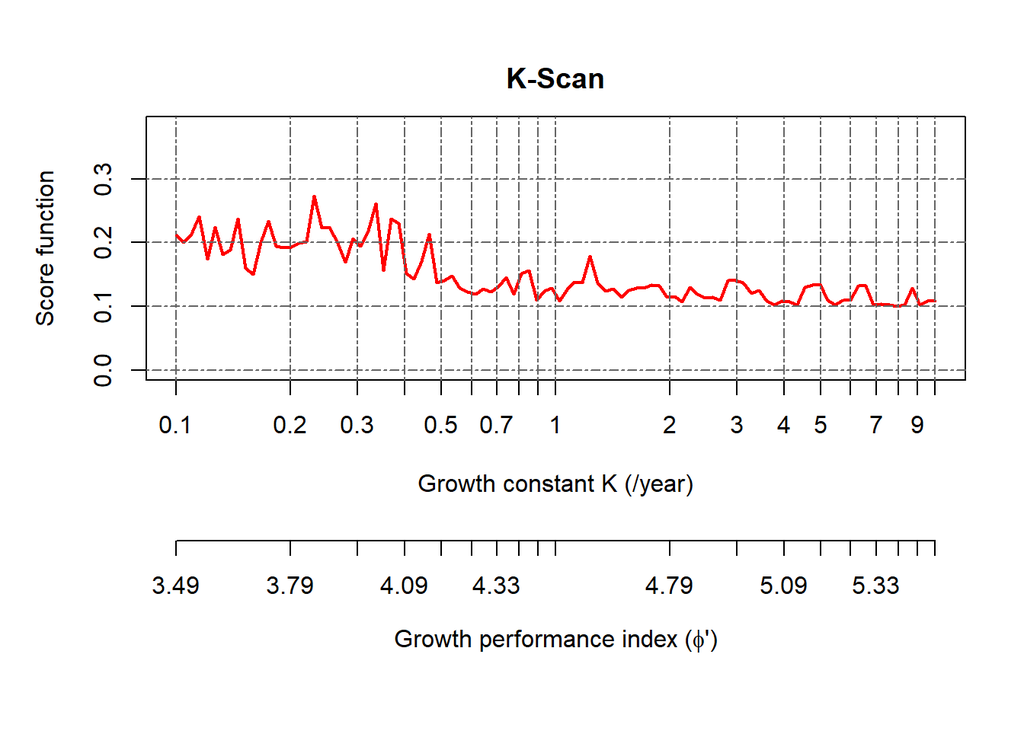

```r
# ELEFAN with K-Scan
res_KScan <- ELEFAN(lfq_mod, Linf_fix = res_PW$Linf_est,
                    MA = 5, addl.sqrt = TRUE, hide.progressbar = TRUE)
```

```r
# show results
res_KScan$par$Linf
```

```
[1] 175.2877
```

```r
res_KScan$par$K
```

```
[1] 0.23
```

### Length-Converted Catch Curve: Estimate F, Z, and Selectivity

**What we’re doing:** Analyze the size structure of the catch to estimate:

- **Z:** Total mortality rate (natural + fishing)
- **F:** Fishing mortality rate (F = Z - M)
- **L50, L95:** Lengths at which 50% and 95% of fish are selected by the fishing gear

**Why it matters:**

- F tells us how heavily the stock is being fished
- Selectivity (L50, L95) shows whether the gear targets juvenile or adult fish
- Together these help us understand current fishing pressure

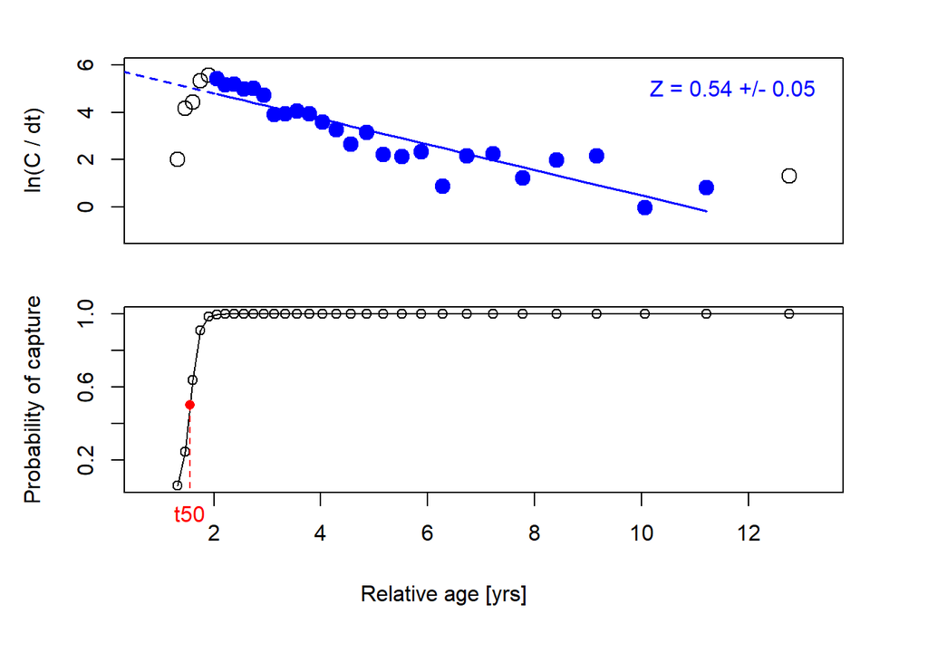

```r
par(mfrow = c(2,1))

ab = lfq_mod |>
  TropFishR::lfqModify(vectorise_catch = TRUE,
                       bin_size = 4,
                       year = 2024)

ab$Linf = res_KScan$par$Linf
ab$K = res_KScan$par$K

catch.converted = ab |>
  TropFishR::catchCurve(reg_int = c(40, 178),
                        calc_ogive = TRUE,
                        auto = TRUE,
                        plot = TRUE)
```

```r
catch.converted$F
```

[output not shown]

### Estimate Natural Mortality Rate (M)

**What we’re doing:** Calculate the natural mortality rate (M)—the death rate from predators, disease, and aging—using an empirical equation based on growth parameters.

**Why it matters:**

- M is needed to separate fishing deaths (F) from natural deaths
- Equation: F = Z - M
- Different species have different natural mortality based on their life history

```r
# estimation of M
Ms <- TropFishR::M_empirical(Linf = res_KScan$par$Linf,
                             K_l = res_KScan$par$K,
                             method = "Then_growth")

lfq_mod$M <- as.numeric(Ms)
```

### Assemble LBSPR Input Parameters

**What we’re doing:**

Compile all the biological and exploitation parameters we’ve estimated into variables ready for the LBSPR model.

**Parameter groups:** - **Biological:** Growth (Linf), maturity (L50, L95), natural mortality (M/K ratio) - **Exploitation:** Gear selectivity (SL50, SL95), fishing pressure (F/M) - **Size classes:** Bins for the analysis (typically 5 cm intervals)

```r
## biological parameters
Species = "Yellowfin"
Linf = res_KScan$par$Linf
L50 = yft_ogive_fq$out |> filter(between(fitted, 0.49, 0.60)) |> slice(1) |> pull(x)
L95 = yft_ogive_fq$out |> filter(between(fitted, 0.938, 0.9510)) |> slice(1) |> pull(x)
MK = lfq_mod$M / res_KScan$par$K

## Exploitation parameters
SL50 = catch.converted$L50
SL95 = catch.converted$L95
FM = catch.converted$FM |> as.numeric() |> abs()

## Size classes
BinWidth = 5
BinMin = yft |> pull(length_cm) |> min()
BinMax = yft |> pull(length_cm) |> max()
L_units = "cm"
```

### Create LBSPR Parameter Object

**What we’re doing:** Create an empty LB_pars object (a special R data structure) to hold all LBSPR model parameters.

```r
yftPars <- new("LB_pars")
```

### Populate LBSPR Parameters

```r
## biological parameters
yftPars@Species = "Yellowfin"
yftPars@Linf = res_KScan$par$Linf
yftPars@L50 = yft_ogive_fq$out |> filter(between(fitted, 0.49, 0.60)) |> slice(1) |> pull(x)
yftPars@L95 = yft_ogive_fq$out |> filter(between(fitted, 0.938, 0.9510)) |> slice(1) |> pull(x)
yftPars@MK = lfq_mod$M / res_KScan$par$K

## Exploitation parameters
yftPars@SL50 = catch.converted$L50
yftPars@SL95 = catch.converted$L95
yftPars@FM = 0.3  # Initial value; model will estimate based on data

## Size classes
yftPars@BinWidth = 5
yftPars@BinMin = yft |> pull(length_cm) |> min()
yftPars@BinMax = 190
yftPars@L_units = "cm"
```

### Run the LBSPR Simulation

```r
yftSim = yftPars |> LBSPRsim()
```

### Visualize LBSPR Results

**What we’re doing:** Create four diagnostic plots showing: - **Top-left:** Expected catch size structure vs. unfished population - **Top-right:** Maturity and selectivity curves overlaid - **Bottom-left:** von Bertalanffy growth curve - **Bottom-right:** Stock status relative to reference points

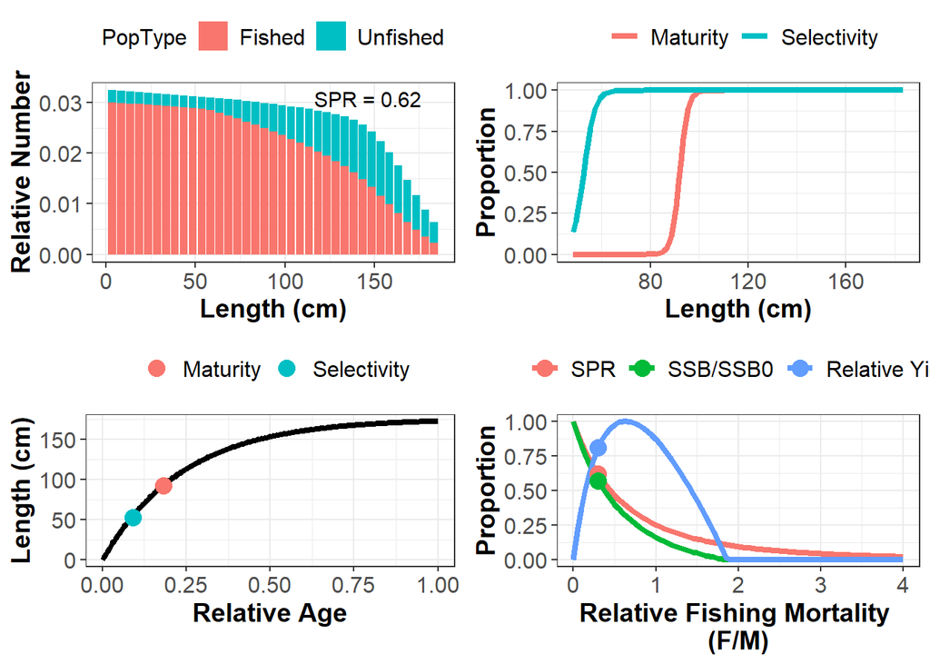

Figure 1: Estimated a) the expected (equilibrium) size structure of the catch and the expected unfished size structure of the vulnerable population, b) the maturity and selectivity-at-length curves, c) the von Bertalanffy growth curve with relative age, and d) the SPR and relative yield curves as a function of relative fishing mortality.

```r
yftSim |>
  plotSim(lf.type = "pop")
```

```r
par(mfrow = c(1,1))

yftSim  |>  plotSim(type = "growth")
yftSim  |>  plotSim(type = "len.freq")
yftSim  |>  plotSim(type = "yield.curve")
```

[output not shown]

```r
yftmetrics = tibble(
    Linf = yftSim@Linf,
    Z = catch.converted$Z,
    K = catch.converted$K,
    t50 = catch.converted$t50,
    t95 = catch.converted$t95,
    L50 = yftSim@L50,
    L95 = yftSim@L95,

    SL50 = yftSim@SL50,
    SL95 = yftSim@SL95,
    MK = yftSim@MK,
    FM = yftSim@FM,

    SPR = yftSim@SPR,
    Yield = yftSim@Yield,
    YPR = yftSim@YPR,
    SSB = yftSim@SSB,
    SSB0 = yftSim@SSB0
    )  |>
  mutate(across(is.numeric, round, 2)) |>
  pivot_longer(cols =1:16) |>
  mutate(Parameters = rep(c('Biological', "Exploitation", "Stock"), c(7,4,5)), .before = name)
```

```r
tuna_metrics_clean = tuna_metrics |> rename(name = 1) |> dplyr::select(-value)

yftmetrics |>
    left_join(tuna_metrics_clean, by = "name") |>
    dplyr::select(1:4) |>
  gt(groupname_col = 'Parameters') |>
  cols_label(
    name = "Metric",
    value = "Value",
    measure = "What It Measures"
  ) |>
  fmt_number(
    columns = value,
    decimals = 2
  ) |>
  tab_style(
    style = cell_text(weight = "bold"),
    locations = cells_column_labels()
  ) |>
  tab_style(
    style = cell_fill(color = "#e8f4f8"),
    locations = cells_body(rows = Parameters %in% c("Biological"))
  ) |>
  tab_style(
    style = cell_fill(color = "#fff3cd"),
    locations = cells_body(rows = Parameters %in% c("Exploitation"))
  ) |>
  tab_style(
    style = cell_fill(color = "#aef6eaff"),
    locations = cells_body(rows = Parameters %in% c("Stock"))
  ) |>
  tab_options(
    table.font.size = 12,
    column_labels.font.weight = "bold",
    row_group.font.weight = "bold"
  ) |>
  cols_width(
    name ~ px(50),
    value ~ px(150),
    measure ~ px(400)
  ) |>
  tab_source_note(
    source_note = "Note: These metrics were computed from yellowfin tuna data of Somalia"
  )
```

Table 1: Stock assessment reference points with descriptions and metric values of yellowfin tuna

[output not shown]

Note: These metrics were computed from yellowfin tuna data of Somalia